# Permutation tests

In this notebook I want to explain the basic ideas behind permutation tests. It is a non-parameteric way of testing statistical hypothesis that is based upon ideas of resampling to generate null-hypothesis distributions–as opposed to relying on a known-distribution under certain assumptions.

We’ll use the following libraries in this notebook.

```r
library(ggplot2)
library(tidyverse)
```

We’ll see if a permutation test can find the difference in scenario 2 without any distributional assumptions! Our sample size will be 50 for each variable.

```r
set.seed(999)
scenario1 <- data_frame(
  scenario = "Scenario 1",
  x = rnorm(50, mean = 0, sd = 0.5),
  y = rnorm(50, mean = 0, sd = 1))
scenario2 <- data_frame(
  scenario = "Scenario 2",
  x = rnorm(50, mean = 0.7, sd = 0.5),
  y = rnorm(50, mean = 0, sd = 1)
)
```

We will be interested in obtaining the difference of the means

```r
experiment_data <- bind_rows(scenario1, scenario2) %>%
  mutate(difference = x - y)
```

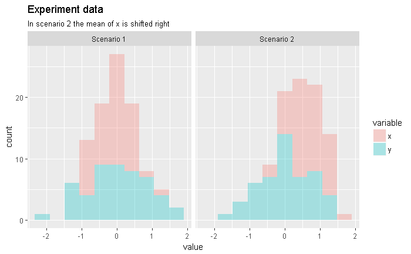

```r
ggdata <- experiment_data %>%
  select(scenario, x, y) %>%
  gather(variable, value, -scenario)
ggplot(ggdata) +
  aes(x = value, fill = variable) +
  geom_histogram(bins = 10, alpha = 0.3) +
  facet_grid(~ scenario) +
  labs(title = "Experiment data",
       subtitle = "In scenario 2 the mean of x is shifted right")
```

The mean of the difference in each scenario is

```r
diff_data <- experiment_data %>%
  group_by(scenario) %>%
  summarise(mean_diff = mean(difference))
diff_data
```

| scenario | mean_diff |
| --- | --- |
| Scenario 1 | -0.1721155 |
| Scenario 2 | 0.5868891 |

Let’s construct a null distribution for the differences where the null is that there is no difference (scenario don’t matter). This will require

> Random shuffling the labels between x and y and computing the mean difference at eachtime.

```r
num_resamples <- 100
```

```r
perm_diffs <- function(x, y, num_resamples) {
  diffs <- numeric(50)
  for (i in 1:num_resamples) {
    perm <- sample(1:2, 50, replace = TRUE)
    xnew <- numeric(50)
    ynew <- numeric(50)
    for (k in 1:50) {
      if (perm[k] == 1) {
         xnew[k] <- x[k]
         ynew[k] <- y[k]
      } else {
         xnew[k] <- y[k]
         ynew[k] <- x[k]
      }
    }
    diffs[i] <- mean(xnew - ynew)
  }
  diffs
}
diff_under_null <- data_frame(
  resample = 1:50,
  `Scenario 1` = perm_diffs(scenario1$x, scenario2$y, 50),
  `Scenario 2` = perm_diffs(scenario2$x, scenario2$y, 50))
head(diff_under_null)
```

| resample | Scenario 1 | Scenario 2 |
| --- | --- | --- |
| 1 | -0.05100921 | -0.01575442 |
| 2 | 0.05282427 | 0.14319391 |
| 3 | -0.02809433 | 0.06272036 |
| 4 | 0.19889741 | 0.17292736 |
| 5 | -0.17749047 | -0.19370991 |
| 6 | 0.01226283 | -0.06730245 |

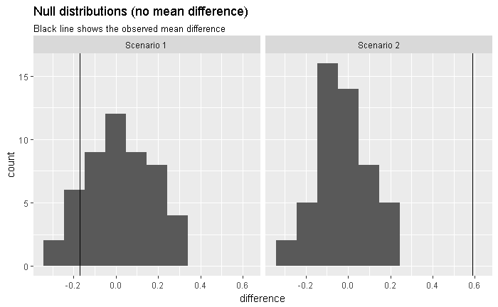

```r
ggdata <- diff_under_null %>%
  gather(scenario, difference, -resample)
ggplot(ggdata, aes(x = difference)) +
  geom_histogram(bins = 10) +
  facet_grid(~scenario) +
  geom_vline(data = diff_data, aes(xintercept = mean_diff)) +
  labs(title = "Null distributions (no mean difference)",
       subtitle = "Black line shows the observed mean difference")
```

Bingo! We see that in the first case there is no strong evidence for a difference (because in reality there’s not!), but in the second case we strongly reject that the means are the same.